# **ICE: Outliers & Missing Data**

## Name: Cabot Steward

## *DATA 3300*

> In this assignment, you will learn how to handle missing data and outliers using Python. The topics covered include determining where data is missing, visualizing missingness, and understanding structurally missing data. You will also explore the concept of data missing at random (MAR) and various imputation techniques for filling in missing values, such as simple imputation and multiple imputation methods.

> Additionally, the assignment will teach you how to visualize outliers, use methods to correct or handle outliers without removing them, and apply transformations to reduce their impact on your analysis. Finally, you will learn how to discretize continuous variables into categorical variables, which can help manage outliers and improve model performance. This comprehensive assignment will equip you with the skills to effectively manage and preprocess your data, ensuring robust and reliable analyses.

### **Client Scenario**

MindWell Health, a pioneering mental health telehealth startup, is dedicated to providing accessible and effective mental health services to individuals working in various industries. To better understand the mental health needs and trends among employees at different companies, MindWell Health has collected an extensive dataset.

The data team at MindWell Health has tasked us with preprocessing this dataset to address challenges related to missing data and outliers.

By correcting these data preprocessing concerns, MindWell Health aims to derive accurate insights from the data, which will inform their service offerings and enable them to tailor mental health interventions. This will help them provide more personalized and effective care, ultimately supporting their mission to enhance mental well-being through innovative telehealth solutions.

### **Data Card**

This dataset contains the following data:

- SurveyID
- Age: free response
- Gender: free response
- Country
- state: If you live in the United States, which state or territory do you live in?
- self_employed: Are you self-employed?
- family_history: Do you have a family history of mental illness?
- treatment: Have you sought treatment for a mental health condition?
- work_interfere: If you have a mental health condition, do you feel that it interferes with your work?
- no_employees: How many employees does your company or organization have?
- remote_work: Do you work remotely (outside of an office) at least 50% of the time?
- tech_company: Is your employer primarily a tech company/organization?
- benefits: Does your employer provide mental health benefits?
- care_options: Do you know the options for mental health care your employer provides?
- wellness_program: Has your employer ever discussed mental health as part of an employee wellness program?
- seek_help: Does your employer provide resources to learn more about mental health issues and how to seek help?
- comments: Any additional notes or comments

**Let's begin by loading in our dependencies that will allow us to visualize our data for missingness and outliers, as well as some functions from `sklearn` that will allow us to impute (or estimate) missing values where appropriate!**

```python
import pandas as pd
import numpy as np
import seaborn as sns
import matplotlib.pyplot as plt

from sklearn.impute import SimpleImputer
from sklearn.experimental import enable_iterative_imputer
from sklearn.impute import IterativeImputer

pd.set_option('display.max_columns', None)
```

```python
df = pd.read_csv('Tech_MentalHealth.csv')
# display data
df.head()
```

|  | SurveyID | Age | Gender | Country | state | self_employed | family_history | treatment | work_interfere | no_employees | remote_work | tech_company | benefits | care_options | wellness_program | seek_help | comments |
| --- | --- | --- | --- | --- | --- | --- | --- | --- | --- | --- | --- | --- | --- | --- | --- | --- | --- |
| 0 | 1 | 37.0 | Female | United States | IL | No | No | Yes | Often | 2347 | No | Yes | Yes | Not sure | No | Yes | NaN |
| 1 | 2 | 44.0 | M | United States | IN | No | No | No | Rarely | 3126 | No | No | Don't know | No | Don't know | Don't know | NaN |
| 2 | 3 | 32.0 | Male | Canada | NaN | No | No | No | Rarely | 1360 | No | Yes | No | No | No | No | NaN |
| 3 | 4 | NaN | Male | United Kingdom | NaN | No | Yes | Yes | Often | 492 | No | Yes | No | Yes | No | No | NaN |
| 4 | 5 | 31.0 | Male | United States | TX | No | No | No | Never | 769 | Yes | Yes | Yes | No | Don't know | Don't know | NaN |

**One way we can check for missingness is just simply using df.info(). How many total observations do we have, and do any columns contain missing values?**

```python
# show info
df.info()

# we have 1248 entries
# age, state, work_interference, comments
```

```
<class 'pandas.core.frame.DataFrame'>
RangeIndex: 1248 entries, 0 to 1247
Data columns (total 17 columns):
 #   Column            Non-Null Count  Dtype
---  ------            --------------  -----
 0   SurveyID          1248 non-null   int64
 1   Age               1221 non-null   float64
 2   Gender            1248 non-null   object
 3   Country           1248 non-null   object
 4   state             744 non-null    object
 5   self_employed     1248 non-null   object
 6   family_history    1248 non-null   object
 7   treatment         1248 non-null   object
 8   work_interfere    987 non-null    object
 9   no_employees      1248 non-null   int64
 10  remote_work       1248 non-null   object
 11  tech_company      1248 non-null   object
 12  benefits          1248 non-null   object
 13  care_options      1248 non-null   object
 14  wellness_program  1248 non-null   object
 15  seek_help         1248 non-null   object
 16  comments          162 non-null    object
dtypes: float64(1), int64(2), object(14)
memory usage: 165.9+ KB
```

# we have 1248 entries

# age, state, work_interference, comments

## Visualizing Missing Data

**This isn't a great way to absorb this informaiton, or understand patterns of missingness however, so let's use some additional visualizations...**

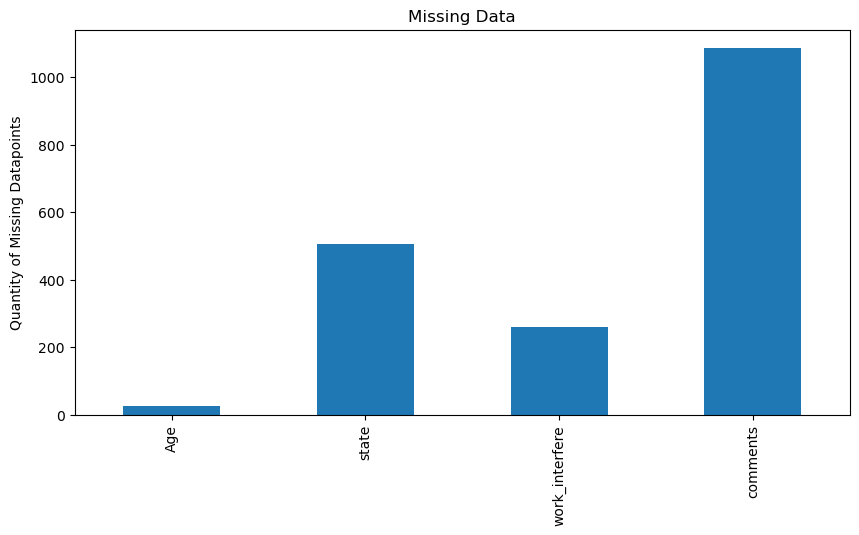

```python
# Create a bar plot of missing data
missing_data = df.isnull().sum()
plt.figure(figsize=(10,5))
missing_data[missing_data > 0].plot(kind='bar')
plt.title('Missing Data')
plt.ylabel('Quantity of Missing Datapoints')
plt.show()
```

**Which variable has the most missing data, and does it make sense that this column has the most missing values?**

comments, yes

**Next, let's use a heatmap visualization that allows us to see missingess across participants and variables...**

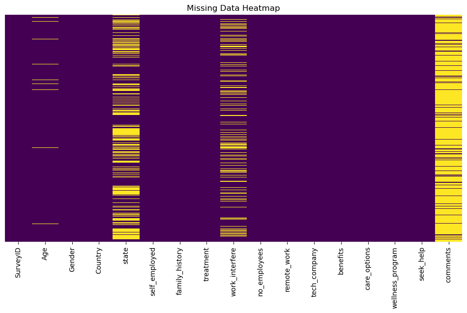

```python
plt.figure(figsize=(12,6))
sns.heatmap(df.isnull(), cmap='viridis', cbar=False, yticklabels=False)
plt.title('Missing Data Heatmap')
plt.show()
```

**We'll zoom in a bit on one section...**

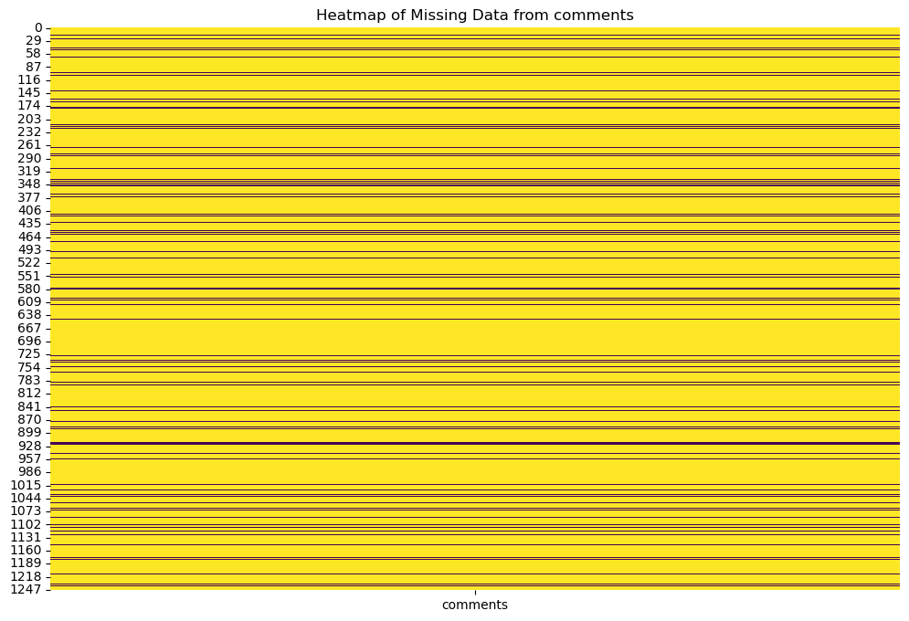

```python
df_sub = df[['comments']]
plt.figure(figsize=(12, 8))
sns.heatmap(df_sub.isnull(), cbar=False, cmap="viridis")
plt.title('Heatmap of Missing Data from comments')
plt.show()
```

**What if any patterns appear amongst the missing data collectively across variables?**

- The nulls are generally on columns that dont matter as much
- comments are generally left null

**Let's examine just State and Country, and look at observations where state is missing. Is there a structural reason why state is missing? How can we deal with this form of missingness?**

```python
# pull up just columns state and Country and observations where state is missing
df[['state', 'Country']][df['state'].isnull()]
```

|  | state | Country |
| --- | --- | --- |
| 2 | NaN | Canada |
| 3 | NaN | United Kingdom |
| 7 | NaN | Canada |
| 9 | NaN | Canada |
| 11 | NaN | Bulgaria |
| ... | ... | ... |
| 1233 | NaN | United Kingdom |
| 1234 | NaN | Australia |
| 1236 | NaN | Finland |
| 1240 | NaN | South Africa |
| 1243 | NaN | United Kingdom |

504 rows × 2 columns

```python
# where country is United States, check for NaNs in the state column
df[df['state'] == "United States"]['state'].isnull().sum()
```

```
0
```

Negative

## Fill in NaNs with New Value

```python
# fill in NaNs in the state column with the text 'NA'

df['state'].replace({np.nan:"NA"})
df.head()
```

|  | SurveyID | Age | Gender | Country | state | self_employed | family_history | treatment | work_interfere | no_employees | remote_work | tech_company | benefits | care_options | wellness_program | seek_help | comments |
| --- | --- | --- | --- | --- | --- | --- | --- | --- | --- | --- | --- | --- | --- | --- | --- | --- | --- |
| 0 | 1 | 37.0 | Female | United States | IL | No | No | Yes | Often | 2347 | No | Yes | Yes | Not sure | No | Yes | NaN |
| 1 | 2 | 44.0 | M | United States | IN | No | No | No | Rarely | 3126 | No | No | Don't know | No | Don't know | Don't know | NaN |
| 2 | 3 | 32.0 | Male | Canada | NaN | No | No | No | Rarely | 1360 | No | Yes | No | No | No | No | NaN |
| 3 | 4 | NaN | Male | United Kingdom | NaN | No | Yes | Yes | Often | 492 | No | Yes | No | Yes | No | No | NaN |
| 4 | 5 | 31.0 | Male | United States | TX | No | No | No | Never | 769 | Yes | Yes | Yes | No | Don't know | Don't know | NaN |

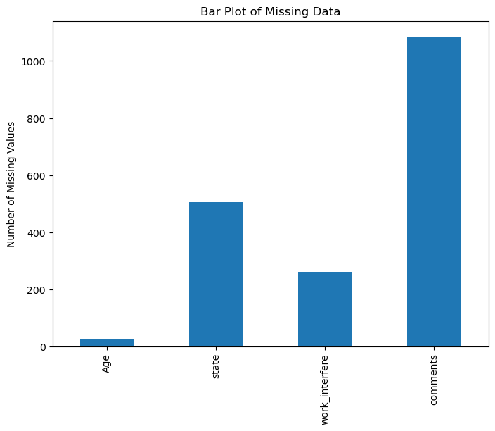

```python
# Create a bar plot of missing data
missing_data = df.isnull().sum()
plt.figure(figsize=(8, 6))
missing_data[missing_data > 0].plot(kind='bar')
plt.title('Bar Plot of Missing Data')
plt.ylabel('Number of Missing Values')
plt.show()
```

**What does the work_interfere variable indicate on the survey, what type of missing data is suspected?**

- work_interfere: If you have a mental health condition, do you feel that it interferes with your work?

if its missing its likely that they don't have a mental health condition

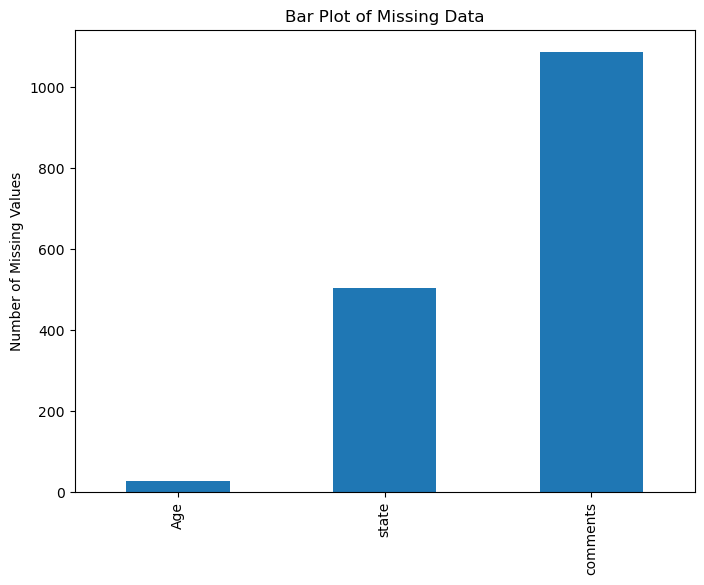

```python
df['work_interfere'].fillna('No mental health condition', inplace=True)

missing_data = df.isnull().sum()
plt.figure(figsize=(8, 6))
missing_data[missing_data > 0].plot(kind='bar')
plt.title('Bar Plot of Missing Data')
plt.ylabel('Number of Missing Values')
plt.show()
```

**Finally, let's investigate Age. What type of missing variable is it likely NOT to be?**

Not a string or to large of number

## Visualizing Patterns of Missingess Against other Variables

```python
df.columns
```

```
Index(['SurveyID', 'Age', 'Gender', 'Country', 'state', 'self_employed',
       'family_history', 'treatment', 'work_interfere', 'no_employees',
       'remote_work', 'tech_company', 'benefits', 'care_options',
       'wellness_program', 'seek_help', 'comments'],
      dtype='object')
```

**Let's examine Age missingess against other variables to see if any patterns emerge...**

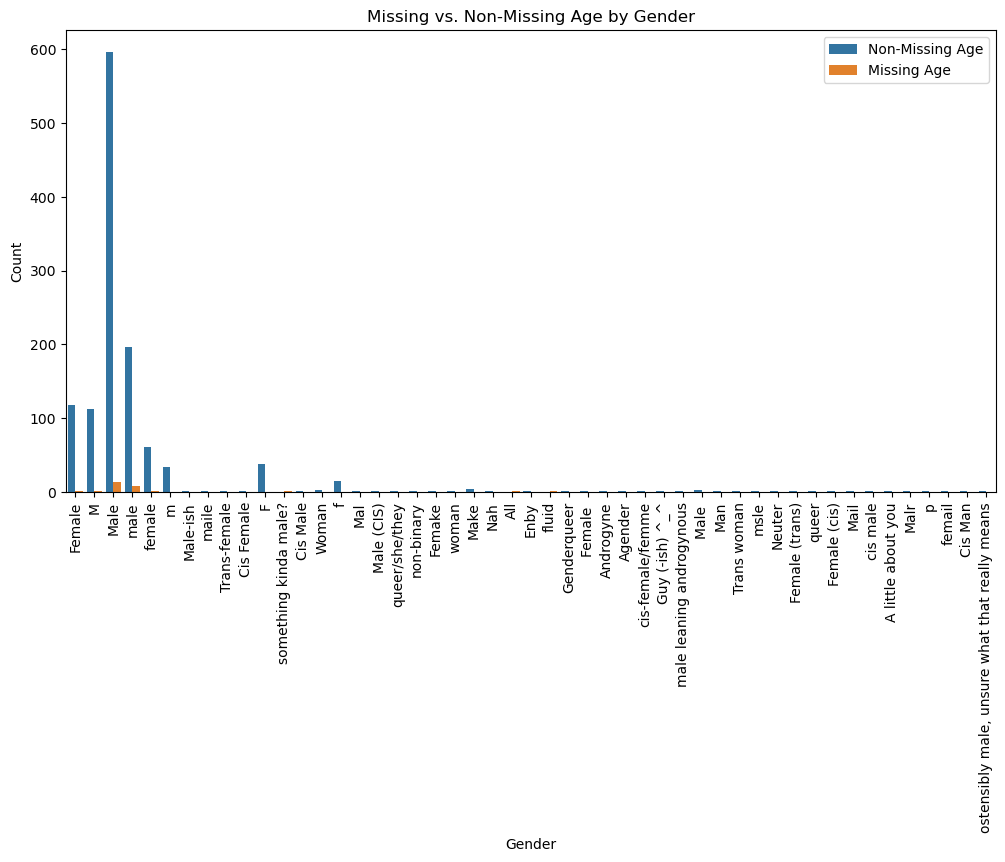

```python
# Create a boolean mask for missing Age values
df['missing_age'] = df['Age'].isnull().astype(int)

plt.figure(figsize=(12, 6))
sns.countplot(data=df, x='Gender', hue='missing_age')
plt.title('Missing vs. Non-Missing Age by Gender')
plt.xlabel('Gender')
plt.ylabel('Count')
plt.legend(['Non-Missing Age', 'Missing Age'])
plt.xticks(rotation=90)
plt.show()
```

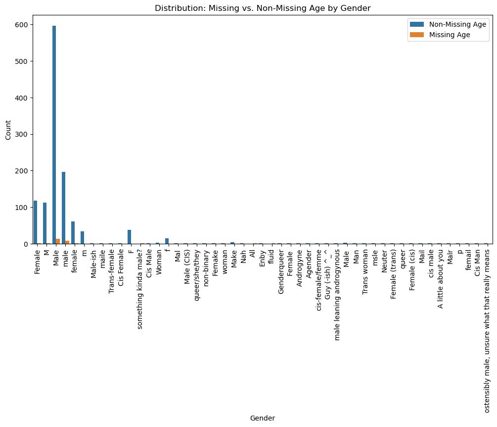

```python
df['missing_age_mask'] = df['Age'].isnull().astype(int)
plt.figure(figsize=(12, 6))
sns.countplot(data=df, x='Gender', hue='missing_age_mask')
plt.title('Distribution: Missing vs. Non-Missing Age by Gender')
plt.xlabel('Gender')
plt.ylabel('Count')
plt.legend(['Non-Missing Age', 'Missing Age'])
plt.xticks(rotation=90)
plt.show()
```

**What do these patterns indicate about the type of missingness?**

there are also missing values that are in the dataset, such as Nah

## Visualizing Outliers

**One way to impute missing data is to simply fill in missing values with the mean of age (simple imputation). What should we check before we use the mean?**

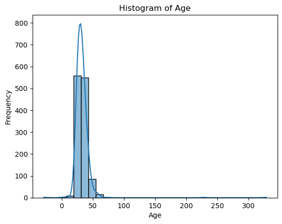

```python
# plot histogram
sns.histplot(df['Age'], bins=30, kde=True)
plt.title('Histogram of Age')
plt.xlabel('Age')
plt.ylabel('Frequency')
plt.show()
```

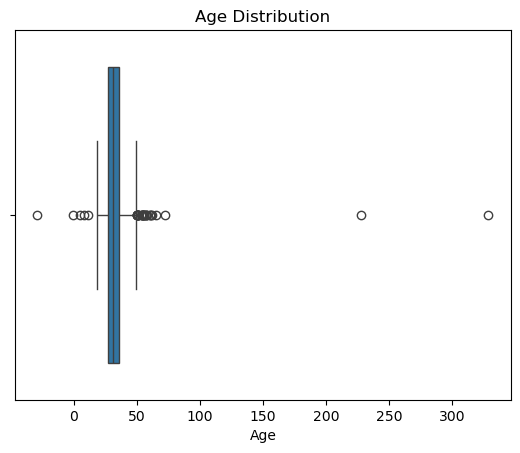

```python
sns.boxplot(x=df['Age'])
plt.title('Age Distribution')
plt.xlabel('Age')
plt.show()
```

```python
# describe Age
df['Age'].describe()
```

```
count    1221.000000
mean       32.320229
std        12.702839
min       -29.000000
25%        27.000000
50%        31.000000
75%        36.000000
max       329.000000
Name: Age, dtype: float64
```

**Are there any outliers? If so, do any seem to be issues of accuracy? How might we address those?**

Yes there are outliers, we could get rid of any above 100, potentially divide them by 10

```python
# show the index number of the outlier data points for Age
Q1 = df['Age'].quantile(0.25)
Q3 = df['Age'].quantile(0.75)
IQR = Q3 - Q1

lower_bound = Q1 - 1.5 * IQR
upper_bound = Q3 + 1.5 * IQR

outliers = df[df['Age'] < lower_bound].index.tolist() + df[df['Age'] > upper_bound].index.tolist()
outlier_df = df.loc[outliers]

# display outliers
outlier_df.head()
```

|  | SurveyID | Age | Gender | Country | state | self_employed | family_history | treatment | work_interfere | no_employees | remote_work | tech_company | benefits | care_options | wellness_program | seek_help | comments | missing_age | missing_age_mask |
| --- | --- | --- | --- | --- | --- | --- | --- | --- | --- | --- | --- | --- | --- | --- | --- | --- | --- | --- | --- |
| 142 | 143 | -29.0 | Male | United States | MN | No | No | No | No mental health condition | 4808 | Yes | No | Yes | No | Don't know | Yes | NaN | 0 | 0 |
| 727 | 728 | 5.0 | Male | United States | OH | No | No | No | No mental health condition | 1364 | No | Yes | Don't know | Not sure | No | No | We had a developer suffer from depression and ... | 0 | 0 |
| 979 | 980 | 8.0 | A little about you | Bahamas, The | IL | Yes | Yes | Yes | Often | 4978 | Yes | Yes | Yes | Yes | Yes | Yes |  | 0 | 0 |
| 1079 | 1080 | 11.0 | male | United States | OH | Yes | No | No | Never | 3157 | Yes | Yes | No | Yes | No | No | NaN | 0 | 0 |
| 1116 | 1117 | -1.0 | p | United States | AL | Yes | Yes | Yes | Often | 3474 | Yes | Yes | Yes | Yes | Yes | Yes | password: testered | 0 | 0 |

```python
df['Age'].replace({-29: 29, 228: 28, 329: 29}, inplace=True) # in the Age column, replace -29, 228 and 329 with 29, 28, and 29 respectively

df['Age'].replace([5, 8, 11, -1], np.nan, inplace=True) # in the Age column, replace the observations where the value is just 5, 8, 11, and -1 with NaN
```

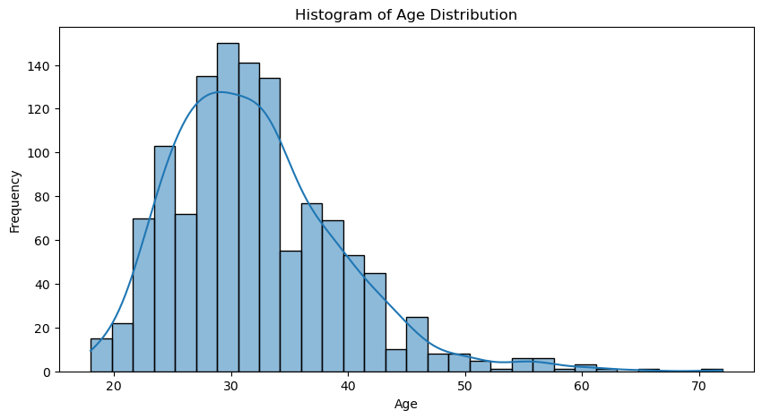

```python
# view hist
plt.figure(figsize=(10, 5))
sns.histplot(df['Age'], bins=30, kde=True)

plt.title('Histogram of Age Distribution')
plt.xlabel('Age')
plt.ylabel('Frequency')

plt.show()
```

**With the extreme outliers that were errors replaced or converted to missing values, should we impute using the mean, median, or most frequent (mode) value?**

median

## Simple Imputation with the Median Value of Age

```python
# Display missing values before imputation
print("Missing values before imputation:")
print(df['Age'].isnull().sum())

imputer = SimpleImputer(strategy='median')

dfi = df.copy()

dfi[['Age']] = imputer.fit_transform(dfi[['Age']])

print("Missing values after imputation:")
print(dfi['Age'].isnull().sum())
```

```
Missing values before imputation:
31
Missing values after imputation:
0
```

```python
# preview dfi
dfi
```

|  | SurveyID | Age | Gender | Country | state | self_employed | family_history | treatment | work_interfere | no_employees | remote_work | tech_company | benefits | care_options | wellness_program | seek_help | comments | missing_age | missing_age_mask |
| --- | --- | --- | --- | --- | --- | --- | --- | --- | --- | --- | --- | --- | --- | --- | --- | --- | --- | --- | --- |
| 0 | 1 | 37.0 | Female | United States | IL | No | No | Yes | Often | 2347 | No | Yes | Yes | Not sure | No | Yes | NaN | 0 | 0 |
| 1 | 2 | 44.0 | M | United States | IN | No | No | No | Rarely | 3126 | No | No | Don't know | No | Don't know | Don't know | NaN | 0 | 0 |
| 2 | 3 | 32.0 | Male | Canada | NaN | No | No | No | Rarely | 1360 | No | Yes | No | No | No | No | NaN | 0 | 0 |
| 3 | 4 | 31.0 | Male | United Kingdom | NaN | No | Yes | Yes | Often | 492 | No | Yes | No | Yes | No | No | NaN | 1 | 1 |
| 4 | 5 | 31.0 | Male | United States | TX | No | No | No | Never | 769 | Yes | Yes | Yes | No | Don't know | Don't know | NaN | 0 | 0 |
| ... | ... | ... | ... | ... | ... | ... | ... | ... | ... | ... | ... | ... | ... | ... | ... | ... | ... | ... | ... |
| 1243 | 1244 | 31.0 | male | United Kingdom | NaN | No | No | Yes | No mental health condition | 3265 | No | Yes | No | No | No | No | NaN | 1 | 1 |
| 1244 | 1245 | 32.0 | Male | United States | IL | No | Yes | Yes | Often | 2749 | Yes | Yes | Yes | Yes | No | No | NaN | 0 | 0 |
| 1245 | 1246 | 34.0 | male | United States | CA | No | Yes | Yes | Sometimes | 825 | No | Yes | Yes | Yes | No | No | NaN | 0 | 0 |
| 1246 | 1247 | 46.0 | f | United States | NC | No | No | No | No mental health condition | 4797 | Yes | Yes | No | Yes | No | No | NaN | 0 | 0 |
| 1247 | 1248 | 25.0 | Male | United States | IL | No | Yes | Yes | Sometimes | 3793 | No | No | Yes | Yes | No | No | NaN | 0 | 0 |

1248 rows × 19 columns

**Are there any potential issues with this simple method of imputation based on measures of central tendency?**

Yes!

## Multiple Imputation using `Iterative Imputer`

```python
# view columns from df
df.columns
```

```
Index(['SurveyID', 'Age', 'Gender', 'Country', 'state', 'self_employed',
       'family_history', 'treatment', 'work_interfere', 'no_employees',
       'remote_work', 'tech_company', 'benefits', 'care_options',
       'wellness_program', 'seek_help', 'comments', 'missing_age',
       'missing_age_mask'],
      dtype='object')
```

```python
df['from_US'] = [1 if country == "United States" else 0 for country in df['Country']] # let's create some simple new columns for country and gender
df['is_male'] = [1 if Gender == "Male" else 0 for Gender in df['Gender']]
```

```python
# Display missing values before imputation
dfm = df.copy()

features_for_imputation = ['work_interfere', 'no_employees', 'benefits']

for col in features_for_imputation:
    if dfm[col].dtype == 'object':
        dfm[col] = dfm[col].astype('category').cat.codes

iter_imputer = IterativeImputer(max_iter=3, random_state=0)
dfm[['Age']] = iter_imputer.fit_transform(dfm[['Age'] + features_for_imputation])[:, 0].reshape(-1, 1)

print("Missing values after imputation:", dfm['Age'].isnull().sum())
```

```
Missing values after imputation: 0
```

```python
# check dfm
dfm
```

|  | SurveyID | Age | Gender | Country | state | self_employed | family_history | treatment | work_interfere | no_employees | remote_work | tech_company | benefits | care_options | wellness_program | seek_help | comments | missing_age | missing_age_mask | from_US | is_male |
| --- | --- | --- | --- | --- | --- | --- | --- | --- | --- | --- | --- | --- | --- | --- | --- | --- | --- | --- | --- | --- | --- |
| 0 | 1 | 37.000000 | Female | United States | IL | No | No | Yes | 2 | 2347 | No | Yes | 2 | Not sure | No | Yes | NaN | 0 | 0 | 1 | 0 |
| 1 | 2 | 44.000000 | M | United States | IN | No | No | No | 3 | 3126 | No | No | 0 | No | Don't know | Don't know | NaN | 0 | 0 | 1 | 0 |
| 2 | 3 | 32.000000 | Male | Canada | NaN | No | No | No | 3 | 1360 | No | Yes | 1 | No | No | No | NaN | 0 | 0 | 0 | 1 |
| 3 | 4 | 32.159753 | Male | United Kingdom | NaN | No | Yes | Yes | 2 | 492 | No | Yes | 1 | Yes | No | No | NaN | 1 | 1 | 0 | 1 |
| 4 | 5 | 31.000000 | Male | United States | TX | No | No | No | 0 | 769 | Yes | Yes | 2 | No | Don't know | Don't know | NaN | 0 | 0 | 1 | 1 |
| ... | ... | ... | ... | ... | ... | ... | ... | ... | ... | ... | ... | ... | ... | ... | ... | ... | ... | ... | ... | ... | ... |
| 1243 | 1244 | 31.952622 | male | United Kingdom | NaN | No | No | Yes | 1 | 3265 | No | Yes | 1 | No | No | No | NaN | 1 | 1 | 0 | 0 |
| 1244 | 1245 | 32.000000 | Male | United States | IL | No | Yes | Yes | 2 | 2749 | Yes | Yes | 2 | Yes | No | No | NaN | 0 | 0 | 1 | 1 |
| 1245 | 1246 | 34.000000 | male | United States | CA | No | Yes | Yes | 4 | 825 | No | Yes | 2 | Yes | No | No | NaN | 0 | 0 | 1 | 0 |
| 1246 | 1247 | 46.000000 | f | United States | NC | No | No | No | 1 | 4797 | Yes | Yes | 1 | Yes | No | No | NaN | 0 | 0 | 1 | 0 |
| 1247 | 1248 | 25.000000 | Male | United States | IL | No | Yes | Yes | 4 | 3793 | No | No | 2 | Yes | No | No | NaN | 0 | 0 | 1 | 1 |

1248 rows × 21 columns

**Compare the imputed values between the two methods...How do they differ?**

```python
comparison_df = pd.DataFrame({
    'Simple Imputation': dfi.loc[df['Age'].isnull(), 'Age'],
    'Multiple Imputation': dfm.loc[df['Age'].isnull(), 'Age']
})

print(comparison_df)
```

```
      Simple Imputation  Multiple Imputation
3                  31.0            32.159753
16                 31.0            30.735270
37                 31.0            32.003896
60                 31.0            30.808665
92                 31.0            33.000768
106                31.0            31.793390
114                31.0            30.801077
134                31.0            31.872372
169                31.0            33.249892
185                31.0            30.734954
193                31.0            32.055192
215                31.0            33.043965
272                31.0            32.090349
327                31.0            31.990190
```

[output cut: 17 more lines]

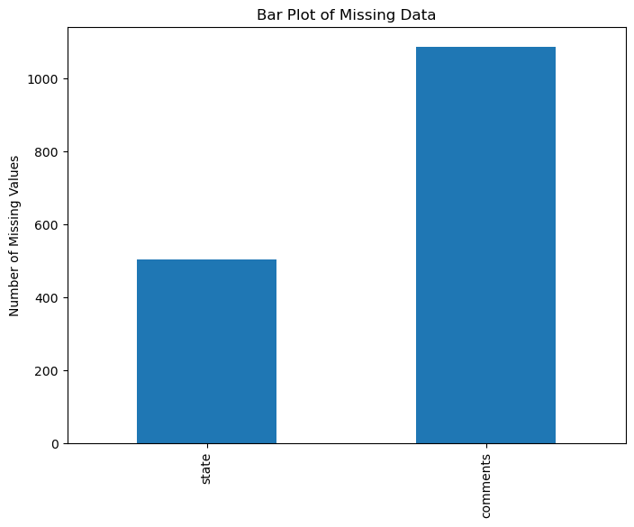

```python
df['Age'] = dfm['Age']# overwrite existing age column with imputed age column

missing_data = df.isnull().sum()
plt.figure(figsize=(8, 6))
missing_data[missing_data > 0].plot(kind='bar')
plt.title('Bar Plot of Missing Data')
plt.ylabel('Number of Missing Values')
plt.show()
```

```python
# describe variable
print(df['Age'].describe())
```

```
count    1248.000000
mean       32.041034
std         7.156150
min        18.000000
25%        27.000000
50%        31.000000
75%        36.000000
max        72.000000
Name: Age, dtype: float64
```

**Are there any likely outliers, how do you know?**

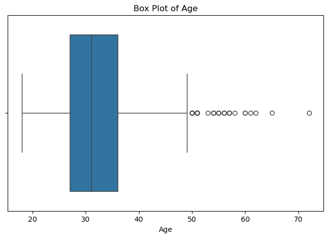

```python
plt.figure(figsize=(8, 5))
sns.boxplot(x=df['Age'])

plt.title('Box Plot of Age')
plt.xlabel('Age')

plt.show()
```

Technically yes but they are within reason

```python
Q1 = df['no_employees'].quantile(0.25)
Q3 = df['no_employees'].quantile(0.75)
IQR = Q3 - Q1

upper_bound = Q3 + 1.5 * IQR

outliers = df[df['no_employees'] > upper_bound].index.tolist()

outlier_df = df.loc[outliers, :]

outlier_df
```

|  | SurveyID | Age | Gender | Country | state | self_employed | family_history | treatment | work_interfere | no_employees | remote_work | tech_company | benefits | care_options | wellness_program | seek_help | comments | missing_age | missing_age_mask | from_US | is_male |
| --- | --- | --- | --- | --- | --- | --- | --- | --- | --- | --- | --- | --- | --- | --- | --- | --- | --- | --- | --- | --- | --- |
| 24 | 25 | 33.0 | male | United States | CA | No | Yes | Yes | Rarely | 50000 | No | Yes | Yes | Not sure | Don't know | Yes | Relatively new job. Ask again later | 0 | 0 | 1 | 0 |
| 155 | 156 | 27.0 | Male | United States | CA | No | Yes | Yes | Sometimes | 61000 | No | Yes | Don't know | No | No | Don't know | NaN | 0 | 0 | 1 | 1 |
| 351 | 352 | 26.0 | male | United States | CA | No | Yes | Yes | Often | 86000 | No | Yes | Yes | Not sure | Don't know | Yes | NaN | 0 | 0 | 1 | 0 |
| 484 | 485 | 30.0 | Male | United States | CA | Yes | Yes | Yes | Often | 66000 | Yes | Yes | No | Yes | No | No | NaN | 0 | 0 | 1 | 1 |

**Looking at these outliers and their other information, do they appear to be inaccurate or true, albeit extreme, data points?**

Looks good, I would replace the NaN in comments with a null

## Transforming Outliers

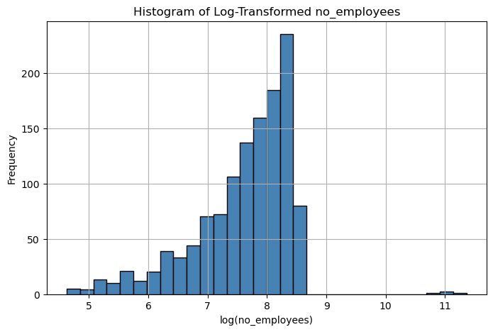

```python
# prompt: perform a log transformation on the no_employees column

df['no_employees_lg'] = np.log1p(df['no_employees'])  # log1p(x) = log(x + 1)

plt.figure(figsize=(8, 5))
df['no_employees_lg'].hist(bins=30, color='steelblue', edgecolor='black')

plt.title('Histogram of Log-Transformed no_employees')
plt.xlabel('log(no_employees)')
plt.ylabel('Frequency')

plt.show()
```

## Binning Outliers

```python
bins = [0, 10, 50, 100, 500, 1000, df['no_employees'].max()]
labels = ['1-10', '11-50', '51-100', '101-500', '501-1000', '1000+']
df['no_employee_cats'] = pd.cut(df['no_employees'], bins=bins, labels=labels) # discretize no_employees in new column
df.head()
```

|  | SurveyID | Age | Gender | Country | state | self_employed | family_history | treatment | work_interfere | no_employees | remote_work | tech_company | benefits | care_options | wellness_program | seek_help | comments | missing_age | missing_age_mask | from_US | is_male | no_employees_lg | no_employee_cats |
| --- | --- | --- | --- | --- | --- | --- | --- | --- | --- | --- | --- | --- | --- | --- | --- | --- | --- | --- | --- | --- | --- | --- | --- |
| 0 | 1 | 37.000000 | Female | United States | IL | No | No | Yes | Often | 2347 | No | Yes | Yes | Not sure | No | Yes | NaN | 0 | 0 | 1 | 0 | 7.761319 | 1000+ |
| 1 | 2 | 44.000000 | M | United States | IN | No | No | No | Rarely | 3126 | No | No | Don't know | No | Don't know | Don't know | NaN | 0 | 0 | 1 | 0 | 8.047829 | 1000+ |
| 2 | 3 | 32.000000 | Male | Canada | NaN | No | No | No | Rarely | 1360 | No | Yes | No | No | No | No | NaN | 0 | 0 | 0 | 1 | 7.215975 | 1000+ |
| 3 | 4 | 32.159753 | Male | United Kingdom | NaN | No | Yes | Yes | Often | 492 | No | Yes | No | Yes | No | No | NaN | 1 | 1 | 0 | 1 | 6.200509 | 101-500 |
| 4 | 5 | 31.000000 | Male | United States | TX | No | No | No | Never | 769 | Yes | Yes | Yes | No | Don't know | Don't know | NaN | 0 | 0 | 1 | 1 | 6.646391 | 501-1000 |

```python
# drop remaining columns not needed
# check for missing values
columns_to_drop = ['SurveyID']  # Add more columns if necessary
df.drop(columns=columns_to_drop, inplace=True)

missing_values = df.isnull().sum()

print("Missing values after cleaning:")
print(missing_values[missing_values > 0])
```

```
Missing values after cleaning:
state        504
comments    1086
dtype: int64
```

**Why is it important we take steps to address missing data and outliers instead of just removing them?**

Removing datapoints can be great and should often be done more often than taking the mean as the mean can skew the data more. BY removing data we can remove other fields that are valuable

**Now go forth with your improved dataset...**

```python
df.to_csv('final.csv') # write to csv
```